# Production and Income

Session 2

Luis F. Gómez L.

luis.gomezl@unimilitar.edu.co

Distance Learning Faculty

29 January, 2026

# Please Read Me

- Check the message **Welcome greeting** published in Announcements forum.
- Dear student please edit your profile uploading a photo where your face is clearly visible.
- If you want to participate, please fill out the following survey: **Primer corte 30% > Learning Activities > Tu opinión sobre la economía colombiana**
- This presentation is based on (Cardenas, 2020, Chapter 2)
- **Purpose**
  - Understand how production is measured using the concept of Gross Domestic Product (GDP)

# Inflation adjustments in GPD

- Initially the Gross Domestic Product is expressed in current Local Currency Units (LCU) which is the sum of monetary values
- A particular monetary value is the product of a quantity and a unit price
- A change in the level of Gross Domestic Product, measure in current LCU, is a combination of changes in quantities and prices
  - Inflation adjustments, applied to GDP, **try** to eliminate the changes of prices
  - There are 2 approaches to make inflation adjustments (ABS, 2003):
    - **Constant price estimates**
    - **Chain volume measures**
- **Chain volume measures** is the alternative used by the Departamento Administrativo Nacional de Estadística (DANE) to make inflation adjustments
  - A gentle introduction to this approach is explained in (ABS, 2003)
  - The monetary values adjusted using **chain volume measures** are not additive. This means that the sum of the components of an aggregate is not necessarily equal to the aggregate
    - In addition to the values adjusted using **chain volume measures**, DANE reports a value known as statistical discrepancy because of non additivity

Table 1: Expenditure/Final demand approach using chain volume measures and expressed in thousands of millions (Colombia)

| Concepto | 2015 | 2023<sup>a</sup> | 2024<sup>b</sup> |
| --- | --- | --- | --- |
| Gasto de consumo final individual de los hogares y las ISFLH<sup>c</sup> | 551,013 | 743,819 | 755,685 |
| Gasto de consumo final individual de los hogares | 547,843 | 740,008 | NA |
| Gasto de consumo final de las ISFLH<sup>c</sup> | 3,170 | 3,826 | NA |
| Gasto de consumo final del gobierno general | 119,188 | 158,899 | 159,974 |
| Formación bruta de capital | 191,305 | 166,571 | 175,282 |
| Exportaciones | 125,936 | 137,800 | 141,310 |
| Importaciones | 182,750 | 228,887 | 238,927 |
| Producto interno bruto | 804,692 | 979,584 | 995,241 |
| Discrepancia estadística | 0 | 1,164 | 1,612 |

<sup>a</sup> Provisional data  
<sup>b</sup> Preliminary data  
<sup>c</sup> Instituciones sin fines de lucro que sirven a los hogares  
Source: DANE - Cuentas Nacionales Anuales - Producto Interno Bruto (PIB) - Series encadenadas de volumen con año de referencia 2015  
Last update: 2025-06-27

Table 2: Expenditure/Final demand approach using current prices and expressed in thousands of millions (Colombia)

| Concepto | 2015 | 2023<sup>a</sup> | 2024<sup>b</sup> |
| --- | --- | --- | --- |
| Gasto de consumo final individual de los hogares y las ISFLH<sup>c</sup> | 551,013 | 1,166,729 | 1,247,678 |
| Gasto de consumo final individual de los hogares | 547,843 | 1,160,241 | 1,240,583 |
| Gasto de consumo final de las ISFLH<sup>c</sup> | 3,170 | 6,488 | 7,095 |
| Gasto de consumo final del gobierno general | 119,188 | 232,203 | 254,078 |
| Formación bruta de capital | 191,305 | 260,497 | 287,059 |
| Exportaciones | 125,936 | 282,554 | 274,726 |
| Importaciones | 182,750 | 357,421 | 357,094 |
| Producto interno bruto | 804,692 | 1,584,562 | 1,706,447 |

<sup>a</sup> Provisional data  
<sup>b</sup> Preliminary data  
<sup>c</sup> Instituciones sin fines de lucro que sirven a los hogares  
Source: DANE - Cuentas Nacionales Anuales - Producto Interno Bruto (PIB) - Precios corrientes  
Last update: 2025-06-27

# Sectors and GDP

Table 3: ISIC adapted for Colombia (DANE, 2022, pp. 134–677)

| Section | Division | Description |
| --- | --- | --- |
| A | 01-03 | Agricultura, ganadería, caza, silvicultura y pesca |
| B | 05-09 | Explotación de minas y canteras |
| C | 10-33 | Industrias manufactureras |
| D | 35 | Suministro de electricidad, gas, vapor, y aire acondicionado |
| E | 36-39 | Distribución de agua; evacuación y tratamiento de aguas residuales, gestión de desechos y actividades de saneamiento ambiental |
| F | 41-43 | Construcción |
| G | 45-47 | Comercio al por mayor y al por menor; reparación de vehículos automotores y motocicletas |
| H | 49-53 | Transporte y almacenamiento |
| I | 55-56 | Alojamiento y servicios de comida |
| J | 58-63 | Información y comunicaciones |
| K | 64-66 | Actividades financieras y de seguros |

Table 4: ISIC adapted for Colombia (DANE, 2022, pp. 134–677)

| Section | Division | Description |
| --- | --- | --- |
| L | 68 | Actividades inmobiliarias |
| M | 69-75 | Actividades profesionales, científicas y técnicas |
| N | 77-82 | Actividades de servicios administrativos y de apoyo |
| O | 84 | Administración pública y defensa; planes de seguridad social de afiliación obligatoria |
| P | 85 | Educación |
| Q | 86-88 | Actividades de atención de la salud humana y de asistencia social |
| R | 90-93 | Actividades artísticas, de entretenimiento y recreación |
| S | 94-96 | Otras actividades de servicios |
| T | 97-98 | Actividades de los hogares en calidad de empleadores; actividades no diferenciadas de los hogares individuales como productores de bienes y servicios para uso propio |
| U | 99 | Actividades de organizaciones y entidades extraterritoriales<sup>a</sup> |

<sup>a</sup> Because of extraterritoriality, in the context of international law, the production units that belong to this category are not part of the domestic territory

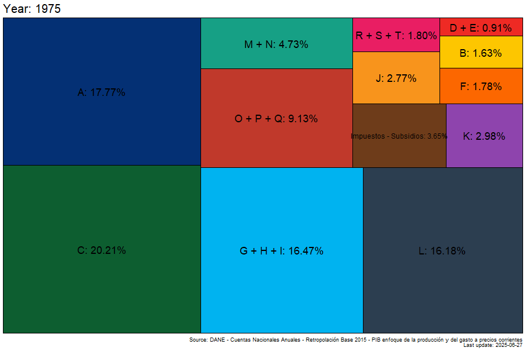

Figure 1: Sectors and share in GDP for Colombia

# Macroeconomic identity

- Uses that firms, non-profit institutions, government bodies, households and the external sector give to production

$$\begin{split}
\mathbf{Demand}_t = & \text{Gasto de consumo final individual de los hogares y las ISFLH}_t + \\
& \text{Gasto de consumo final del gobierno general}_t + \\
& \text{Formación bruta de capital}_t + \\
& \text{Exportaciones}_t \\
= & C_t + G_t + I_t + X_t
\end{split}$$

- Aggregate value generated by the production units in a territory, plus taxes minus subsidies on products, plus products produced outside the territory offered to the territory

$$\begin{split}
\mathbf{Supply}_t = & \text{Valor agregado bruto}_t + \\
& \text{Impuestos menos subvenciones sobre los productos}_t + \\
& \text{Importaciones}_t \\
= & \text{Producto interno bruto}_t + \\
& \text{Importaciones}_t \\
= & GDP_t + M_t
\end{split}$$

$$\begin{split}
\mathbf{Supply}_t & = \mathbf{Demand}_t \\
GDP_t + M_t & = C_t + G_t + I_t + X_t \\
GDP_t & = (C_t + G_t + I_t) + (X_t - M_t)
\end{split}$$

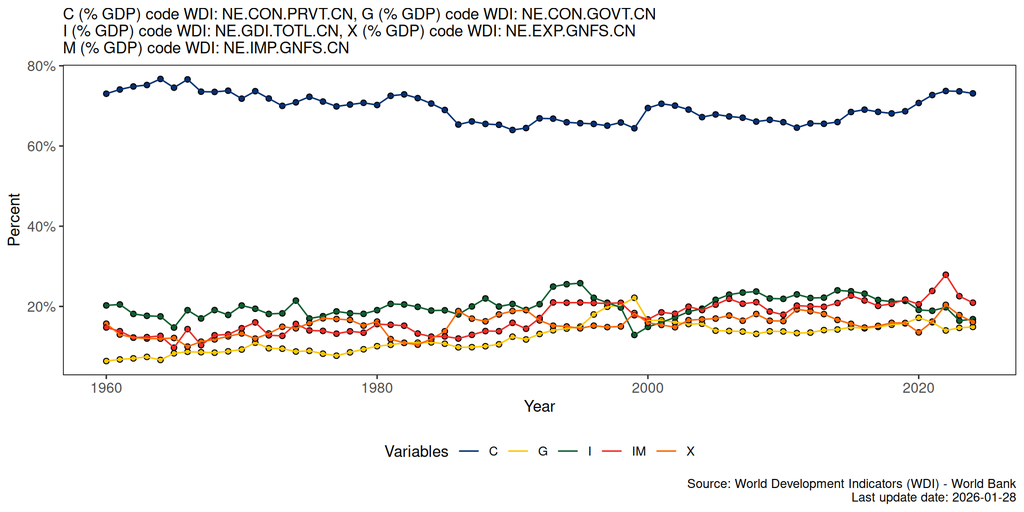

Figure 2: Share of GDP components in Colombia

# Resource of interest

If you want a summary about the topic of Gross Domestic Product check out[^1]:

- Primer corte 30% > Learning Resources > Links of interest > Banco de la República de Colombia - Cátedras de Macroeconomía y Banca Central - Indicadores de actividad económica

# Acknowledgments

- To my family that supports me
- To the taxpayers of Colombia and the [**UMNG students**](https://www.umng.edu.co/estudiante) who pay my salary
- To the [**Business Science**](https://www.business-science.io/) and [**R4DS Online Learning**](https://www.rfordatasci.com/) communities where I learn [**R**](https://www.r-project.org/about.html) and [**$\pi$-thon**](https://www.python.org/about/)
- To the [**R Core Team**](https://www.r-project.org/contributors.html), the creators of [**RStudio IDE**](https://posit.co/download/rstudio-desktop/), [**Positron**](https://positron.posit.co/), [**Quarto**](https://quarto.org/) and the authors and maintainers of the packages [**tidyverse**](https://CRAN.R-project.org/package=tidyverse), [**readxl**](https://CRAN.R-project.org/package=readxl), [**gt**](https://CRAN.R-project.org/package=gt), [**wbstats**](https://CRAN.R-project.org/package=wbstats), [**scales**](https://CRAN.R-project.org/package=scales), [**treemapify**](https://CRAN.R-project.org/package=treemapify), [**gganimate**](https://CRAN.R-project.org/package=gganimate) and [**tinytex**](https://CRAN.R-project.org/package=tinytex) for allowing me to access these tools without paying for a license

# References

ABS. (2003). Demystifying Chain Volume Measures. *Western Australian Statistical Indicators*, 16–25. https://www.ausstats.abs.gov.au/ausstats/subscriber.nsf/0/08CFB1A8C9431C57CA256D030004EE42/$File/13675_mar%202003.pdf

Cardenas, M. (2020). *Introducción a la Economía Colombiana* (4th ed.). Alfaomega.

DANE. (2022). *Clasificación Industrial Internacional Uniforme de todas las actividades económicas Revisión 4 Adaptada para Colombia (2022)*. https://www.dane.gov.co/files/sen/nomenclatura/ciiu/CIIU_Rev_4_AC2022.pdf

## Footnotes

[^1]: Banco de la República de Colombia - Cátedras de Macroeconomía y Banca Central